# Working Report_Black Friday

# Par4: Recommender system

### Brief data exploration 2 for our recommender system

There are 5891 users, 3623 products, 18 Product_Category_1 items, 18 Product_Category_2 items, and 16 Product_Category_3 items. We would have a very large, sparse user-product matrix (i.e. 5891-by-3623 matrix) for our recommender system. The sparsity was estimated to be just around 2% (not shown here).

On the other hand, ‘Product_Category_1’ has no NA values, meaning that any specific product necessarily belongs to one of Product_Category_1 items. However, both ‘Product_Category_2’ and ‘Product_Category_3’ variables have many NA values, meaning that some products are not classified into either of the two categories.

Therefore, Product_Category_1 variable was chosen for the simplicity of our analysis. We have 5891-by-18 user-Product_Category_1 matrix for analysis, and users are going to get recommendations based on product categories.

```r
length(unique(data$User_ID))
```

```
## [1] 5891
```

```r
length(unique(data$Product_ID))
```

```
## [1] 3623
```

```r
length(unique(data$Product_Category_1))
```

```
## [1] 18
```

```r
length(unique(data$Product_Category_2))
```

```
## [1] 18
```

```r
length(unique(data$Product_Category_3))
```

```
## [1] 16
```

```r
sum(is.na(data$Product_Category_1))
```

```
## [1] 0
```

```r
sum(is.na(data$Product_Category_2))
```

```
## [1] 166986
```

```r
sum(is.na(data$Product_Category_3))
```

```
## [1] 373299
```

### Select varaibles for recommender system

First, User_ID and Product_Category_1 variables are picked, and a new column, called ‘Rating_1’, with all values having 1 is added. Here, the fact that a user purchased a product is counted as one rating.

```r
data_recom = cbind(data['User_ID'], data['Product_Category_1'], 1)
colnames(data_recom) = c('User_ID', 'Product_Category_1', 'Rating_1') # rename column names
head(data_recom)
```

```
##   User_ID Product_Category_1 Rating_1
## 1 1000001                  3        1
## 2 1000001                  1        1
## 3 1000001                 12        1
## 4 1000001                 12        1
## 5 1000002                  8        1
## 6 1000003                  1        1
```

### Convert the dataset into the realRatingMatrix form

The three selected variables are converted into the realRatingMatrix form, resulting in 5891-by-18 user-Product_Category_1 matrix. During the conversion process, Rating_1 variables with the same user and the same product are summed up. As a result, for example, we can see in the user-Product_Category_1 matrix that user ID #1000001 bought 11 products that belong to the Product_Category_1 item #3. Also, we can see that user ID #1000001 didn’t bought any product that belongs to the Product_Category_1 item #7.

```r
data_matrix = as(data_recom, Class = 'realRatingMatrix')

data_matrix
```

```
## 5891 x 18 rating matrix of class 'realRatingMatrix' with 52371 ratings.
```

```r
dim(data_matrix) # Dimensions of this realRatingMatrix
```

```
## [1] 5891   18
```

```r
head(as(data_matrix,'matrix'))
```

```
##          1  2  3  4  5  6  7  8  9 10 11 12 13 14 15 16 17 18
## 1000001  4  1 11  2  2  1 NA  8 NA NA NA  3 NA  1 NA  1 NA NA
## 1000002 31  1 NA NA 13  6 NA 25 NA NA NA NA NA NA NA NA NA NA
## 1000003 15  2  1 NA  9 NA NA  1 NA NA NA NA NA NA NA NA NA  1
## 1000004 13 NA NA NA NA NA NA NA NA NA NA NA NA NA NA NA NA NA
## 1000005 18  2  1  3 20  6  5 44 NA NA  2 NA NA  1  1  3 NA NA
## 1000006  8  3  5  5 12  1 NA  6 NA NA NA  3 NA NA NA NA NA  3
```

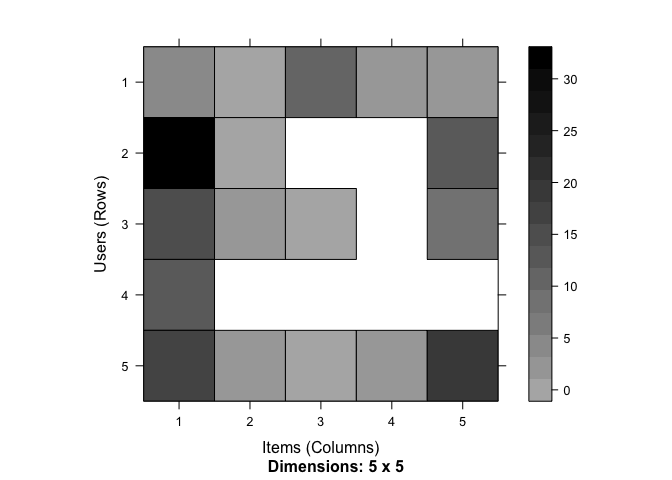

```r
image(data_matrix[1:5,1:5]) # Implementation of image by recommenderlab generates a heatmap.
```

## Sparsity Check

On a side note, the user-Product_Category_1 matrix contains a number of missing values. This is a sparse matrix with 49.38% elements rated.

```r
nratings(data_matrix)/(ncol(data_matrix)*nrow(data_matrix))
```

```
## [1] 0.493889
```

## Exploring Data

The first plot shows the number of users who bought products that belong to each of Product_Category_1 items. Products that belong to Product_Category_1 item #1, #5, and #8 are most purchased, while products that belong to Product_Category_1 item #9 and #17 are least purchased. The second plot shows the number of users who bought products that belong to a specific number of Product_Category_1 items. The number of users who bought products, each of which belongs to one of six Product_Category_1 items, is the highest.

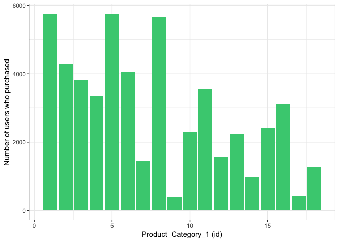

```r
data.frame(no_of_ratings=colCounts(data_matrix))%>%
  rownames_to_column()%>%
  ggplot(aes(x=as.numeric(gsub(rowname,pattern = '[a-z]',replacement = '')), y=no_of_ratings))+
  geom_col(fill='seagreen3')+xlab('Product_Category_1 (id)')+ylab('Number of users who purchased') + theme_bw()
```

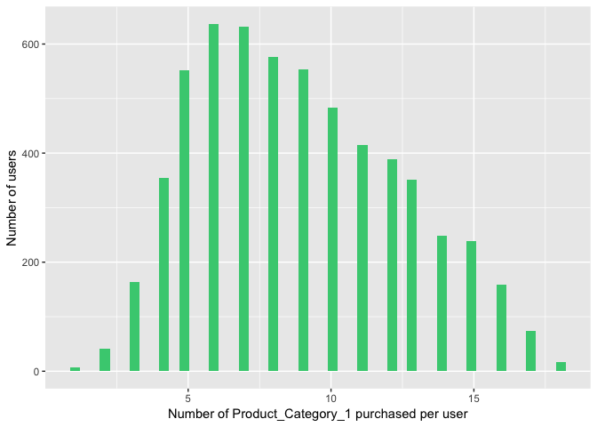

```r
ggplot(data=data.frame(no_of_jokes_rated = rowCounts(data_matrix)),aes(x=no_of_jokes_rated))+
  geom_histogram(bins=50,fill='seagreen3')+ylab('Number of users')+xlab('Number of Product_Category_1 purchased per user')
```

## Comparison of before and after normalizations

Every user has his or her own income and spending plan. Therefore, the total number of purchases or the average number of purchases are different for each user. The first plot shows this distribution. The data should be normalized for each user for recommender system analysis. The second plot shows the distribution after normalization, proving that every user’s average number of purchases is centered to zero.

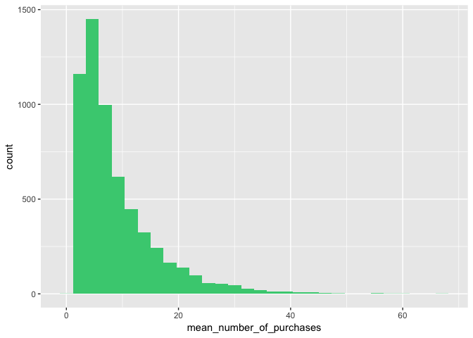

```r
# before normalization
ggplot(data=data.frame(mean_number_of_purchases = rowMeans(data_matrix)),aes(x=mean_number_of_purchases))+
  geom_histogram(fill='seagreen3')
```

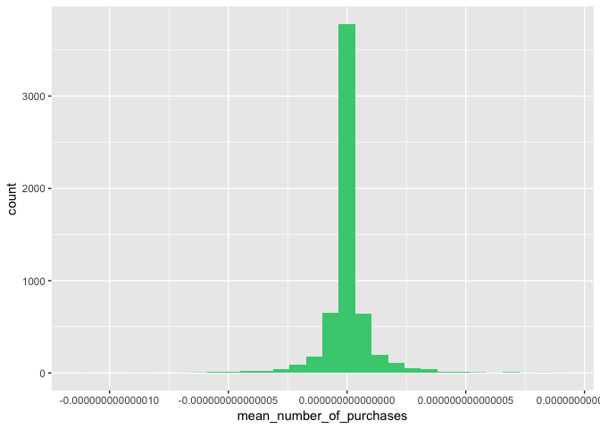

```r
# after normalization
ggplot(data=data.frame(mean_number_of_purchases = rowMeans(normalize(data_matrix))),aes(x=mean_number_of_purchases))+
  geom_histogram(fill='seagreen3')
```

### Similarity matrix

Cosine similarity is examined for some five users. User Id #1000005 and #1000009 show the highest similarity in this case. Both users most purchased products that belong to Product_Category_1 item #1, #5, and #8.

(cf. Recommenderlab functions perform normalizing and compute similarity measures within the Recommender function, so in practice there is no need to perform these functions earlier.)

```r
similarity(normalize(data_matrix)[c(1,3,5,7,9)],method = 'cosine')
```

```
##            1000001    1000003    1000005    1000007
## 1000003 0.33846326
## 1000005 0.36868988 0.10956534
## 1000007 0.76338629 0.65802421 0.35762494
## 1000009 0.40042617 0.01204479 0.92362124 0.61033814
```

```r
# similarity(normalize(data_matrix)[c(1,3,5,7,9)],method = 'pearson')
# similarity(normalize(data_matrix)[c(1,3,5,7,9)],method = 'euclidean')

as(data_matrix,'matrix')[c(5,9),]
```

```
##          1  2 3  4  5 6 7  8  9 10 11 12 13 14 15 16 17 18
## 1000005 18  2 1  3 20 6 5 44 NA NA  2 NA NA  1  1  3 NA NA
## 1000009 11 NA 5 NA  9 7 1 21 NA NA NA NA NA NA  1  2 NA NA
```

### Exploration of functions and their default parameters

```r
names(recommenderRegistry$get_entries(dataType='realRatingMatrix'))
```

```
## [1] "ALS_realRatingMatrix"          "ALS_implicit_realRatingMatrix"
## [3] "IBCF_realRatingMatrix"         "POPULAR_realRatingMatrix"
## [5] "RANDOM_realRatingMatrix"       "RERECOMMEND_realRatingMatrix"
## [7] "SVD_realRatingMatrix"          "SVDF_realRatingMatrix"
## [9] "UBCF_realRatingMatrix"
```

```r
recommenderRegistry$get_entries(data='realRatingMatrix')$UBCF_realRatingMatrix
```

```
## Recommender method: UBCF for realRatingMatrix
## Description: Recommender based on user-based collaborative filtering.
## Reference: NA
## Parameters:
##     method nn sample normalize
## 1 "cosine" 25  FALSE  "center"
```

```r
recommenderRegistry$get_entries(data='realRatingMatrix')$IBCF_realRatingMatrix
```

```
## Recommender method: IBCF for realRatingMatrix
## Description: Recommender based on item-based collaborative filtering.
## Reference: NA
## Parameters:
##    k   method normalize normalize_sim_matrix alpha na_as_zero
## 1 30 "Cosine"  "center"                FALSE   0.5      FALSE
```

### Setting for recommender algorithms

```r
set.seed(1031)
# es = evaluationScheme(data_matrix, method='cross-validation', k=10, given=4)
# es = evaluationScheme(data_matrix, method='cross-validation', k=10, given=1)
es = evaluationScheme(data_matrix, method='cross-validation', k=10, given=-1)
```

### Comparison of recommender algorithms

Considered are 4 recommender algorithms: Random, Popular, User-based Collaborative Filtering (UBCF), and Item-based Collaborative Filtering (IBCF). For both UBCF and IBCF, optimized parameter sets were found. UBCF with an optimized parameter set (nn=400, method=‘euclidean’) showed the lowest RMSE (i.e. 14.07137).

```r
recommender_algorithms = list(random = list(name='RANDOM'),
                              popular = list(name='POPULAR'),
                              ubcf = list(name='UBCF'),
                              # ubcf_100 = list(name='UBCF', parameters=list(nn=100)),
                              # ubcf_400 = list(name='UBCF', parameters=list(nn=400)),
                              # ubcf_1600 = list(name='UBCF', parameters=list(nn=1600)),
                              # ubcf_400_zsco = list(name='UBCF', parameters=list(nn=400, normalize='Z-score')),
                              # ubcf_400_pear = list(name='UBCF', parameters=list(nn=400, method='pearson')),
                              ubcf_400_eucl = list(name='UBCF', parameters=list(nn=400, method='euclidean')),
                              ibcf = list(name='IBCF'),
                              # ibcf_60 = list(name='IBCF', parameters=list(k=60)),
                              # ibcf_120 = list(name='IBCF', parameters=list(k=120)),
                              # ibcf_60_zsco = list(name='IBCF', parameters=list(k=60, normalize='Z-score')),
                              # ibcf_60_pear = list(name='IBCF', parameters=list(k=60, method='pearson')),
                              ibcf_60_eucl = list(name='IBCF', parameters=list(k=60, method='euclidean')))
ev = evaluate(x = es,method=recommender_algorithms, type='ratings')
```

[output not shown]

[output cut: 51 more lines]

```r
results = matrix(unlist(avg(ev)), ncol=3, byrow = TRUE)
colnames(results) = c('RMSE','MSE','MAE')
rownames(results) = c('random','popular',
                      'ubcf','ubcf_400_eucl','ibcf','ibcf_60_eucl')
                      # 'ubcf','ubcf_100','ubcf_400','ubcf_1600','ubcf_400_zsco','ubcf_400_pear','ubcf_400_eucl',
                      # 'ibcf','ibcf_60','ibcf_120','ibcf_60_zsco','ibcf_60_pear','ibcf_60_eucl')
results # ubcf_400_eucl 13.77110 191.2506  7.484053
```

```
##                   RMSE      MSE       MAE
## random        22.30246 500.2232 12.013777
## popular       15.78478 251.7843  9.457947
## ubcf          17.35862 304.3325  8.941396
## ubcf_400_eucl 14.07137 200.7826  7.557017
## ibcf          19.57840 386.7739  9.777727
## ibcf_60_eucl  15.60401 246.6891  6.784803
```

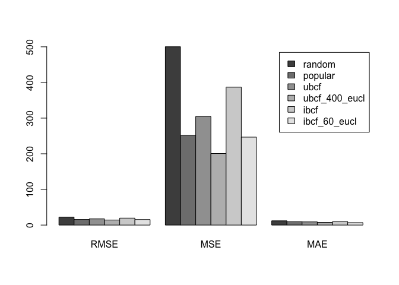

```r
plot(ev)
```

### Top n recommendations

Through the optimized UBCF algorithm, first 5 users are recommended 5 unpurchased product categories. For example, user id #1000001 is turned out to be most likely to purchase products that belong to Product_Category_1 item #9, #17, #18, #13, and #7 in order.

```r
recom_ubcf = Recommender(data_matrix, method='UBCF', parameter=list(normalize='center', nn=400, method='euclidean'))

pred_ubcf_topN = predict(recom_ubcf,newdata=data_matrix,method='topNList',n=5)
getList(pred_ubcf_topN)[1:5]
```

```
## $`1000001`
## [1] "9"  "17" "18" "13" "7"
##
## $`1000002`
## [1] "9"  "17" "14" "7"  "18"
##
## $`1000003`
## [1] "17" "14" "9"  "7"  "12"
##
## $`1000004`
## [1] "5"  "8"  "9"  "17" "18"
##
## $`1000005`
## [1] "9"  "17" "18" "12" "10"
```

### Ratings

Also, their predicted purchase numbers for each unpurchased product categories were identified. For example, user id #1000001 is turned out to be most likely to purchase about 3 (~ 3.229710) products of Product_Category_1 item #7.

In conclusion, we can give each user a customized recommendation and expect to make more profits.

```r
pred_ubcf = predict(recom_ubcf, newdata=data_matrix, type='ratings')

as(data_matrix,'matrix')[1:5,]
```

```
##          1  2  3  4  5  6  7  8  9 10 11 12 13 14 15 16 17 18
## 1000001  4  1 11  2  2  1 NA  8 NA NA NA  3 NA  1 NA  1 NA NA
## 1000002 31  1 NA NA 13  6 NA 25 NA NA NA NA NA NA NA NA NA NA
## 1000003 15  2  1 NA  9 NA NA  1 NA NA NA NA NA NA NA NA NA  1
## 1000004 13 NA NA NA NA NA NA NA NA NA NA NA NA NA NA NA NA NA
## 1000005 18  2  1  3 20  6  5 44 NA NA  2 NA NA  1  1  3 NA NA
```

```r
as(pred_ubcf,'matrix')[1:5,]
```

```
##          1        2        3         4        5         6         7
## 1000001 NA       NA       NA        NA       NA        NA  3.229710
## 1000002 NA       NA 14.08989 13.886827       NA        NA 14.758566
## 1000003 NA       NA       NA  3.661442       NA  3.957081  4.660868
## 1000004 NA 11.54974 11.93281 11.863623 18.55844 11.713537 12.479091
## 1000005 NA       NA       NA        NA       NA        NA        NA
##                8         9        10        11        12        13
## 1000001       NA  3.388235  3.179175  3.142585        NA  3.248409
## 1000002       NA 15.057037 13.857185 14.147114 14.645899 13.906390
## 1000003       NA  4.722999  4.309974  4.242683  4.624595  4.341070
## 1000004 18.21833 12.997436 12.289338 12.398933 12.470307 12.250734
## 1000005       NA  8.710485  6.026244        NA  6.711323  5.736393
##                14        15        16        17        18
## 1000001        NA  3.226391        NA  3.363003  3.282403
## 1000002 14.930502 13.891337 13.686055 15.043166 14.733588
## 1000003  4.743016  4.070224  3.933037  4.791592        NA
## 1000004 12.553968 12.462508 11.747317 12.900363 12.628376
## 1000005        NA        NA        NA  8.044234  6.987679
```